# Aula 8: Regressão Linear e Modelos Mistos

## Introdução

Nesta aula, exploraremos o ajuste de modelos de regressão (linear e polinomial) para descrever a relação entre variáveis contínuas, além de introduzir conceitos de modelos mistos para análise de múltiplos experimentos.

## Preparação do Ambiente

Carregamos as bibliotecas necessárias para manipulação de dados, visualização, importação e modelagem estatística.

```r
library(tidyverse)
library(ggplot2)
library(rio)
library(gsheet)
library(DHARMa)
library(lme4)
library(car)
```

## 1. Regressão Linear Simples (Exemplo Didático)

A regressão linear simples busca ajustar uma reta que melhor descreve a relação entre $X$ e $Y$. O modelo é dado por: $Y = \beta_0 + \beta_1X + \epsilon$.

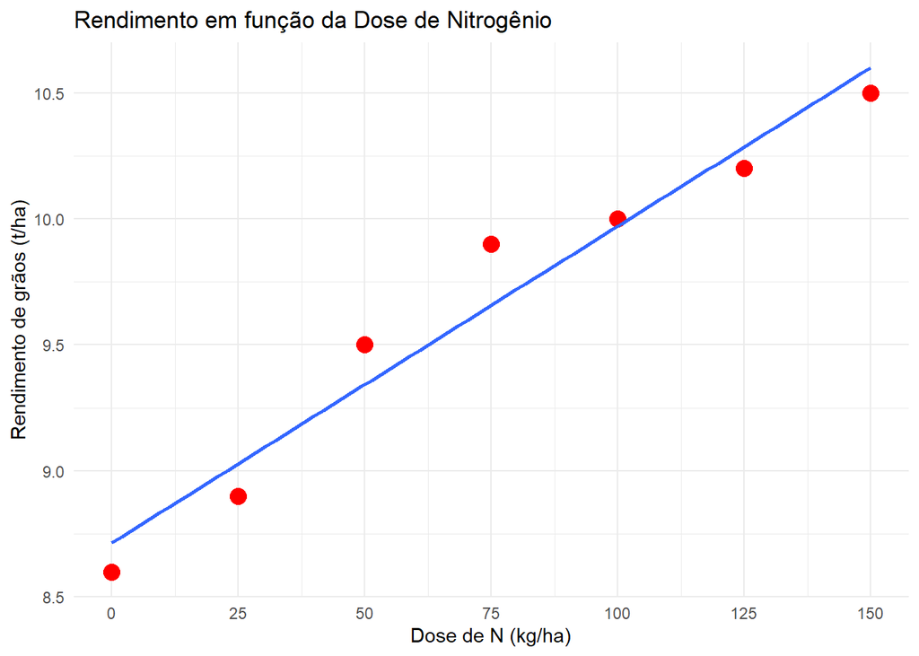

```r
# Criação do conjunto de dados
x <- seq(0, 150, by = 25)
y <- c(8.6, 8.9, 9.5, 9.9, 10, 10.2, 10.5)
df <- data.frame(x = x, y = y)

# Visualização inicial com a reta de regressão
df |> ggplot(aes(x, y)) +
  geom_point(size = 4, color = "red") +
  geom_smooth(se = FALSE, method = "lm") +
  scale_x_continuous(breaks = x) +
  labs(x = "Dose de N (kg/ha)",
       y = "Rendimento de grãos (t/ha)",
       title = "Rendimento em função da Dose de Nitrogênio") +
  theme_minimal()
```

### Ajuste do Modelo e Interpretação

```r
# Ajustar o modelo linear
m1 <- lm(y ~ x, data = df)

# Resumo do modelo
summary(m1)
```

```
Call:
lm(formula = y ~ x, data = df)

Residuals:
       1        2        3        4        5        6        7
-0.11429 -0.12857  0.15714  0.24286  0.02857 -0.08571 -0.10000

Coefficients:
            Estimate Std. Error t value Pr(>|t|)
(Intercept) 8.714286   0.110472   78.88  6.2e-09 ***
x           0.012571   0.001226   10.26 0.000151 ***
---
Signif. codes:  0 '***' 0.001 '**' 0.01 '*' 0.05 '.' 0.1 ' ' 1

Residual standard error: 0.1621 on 5 degrees of freedom
Multiple R-squared:  0.9546,    Adjusted R-squared:  0.9456
F-statistic: 105.2 on 1 and 5 DF,  p-value: 0.0001513
```

```r
# Cálculo de valores preditos e resíduos
pred <- df |>
  mutate(predito = predict(m1),
         residual = y - predito)

pred
```

| x | y | predito | residual |
| --- | --- | --- | --- |
| 0 | 8.6 | 8.714286 | -0.11428571 |
| 25 | 8.9 | 9.028571 | -0.12857143 |
| 50 | 9.5 | 9.342857 | 0.15714286 |
| 75 | 9.9 | 9.657143 | 0.24285714 |
| 100 | 10.0 | 9.971429 | 0.02857143 |
| 125 | 10.2 | 10.285714 | -0.08571429 |
| 150 | 10.5 | 10.600000 | -0.10000000 |

## 2. Regressão Linear com Dados Externos

Nesta seção, importamos dados de produtividade e ajustamos o modelo linear.

```r
url <- "https://bit.ly/df_biostat"
df_reg <- import(url, sheet = "REG_DEL_DATA", setclass = "tbl")

m2 <- lm(RG ~ DOSEN, data = df_reg)
anova(m2)
```

|  | Df | Sum Sq | Mean Sq | F value | Pr(>F) |
| --- | --- | --- | --- | --- | --- |
| DOSEN | 1 | 14.6676321 | 14.66763210 | 359.435 | 2.419233e-13 |
| Residuals | 18 | 0.7345345 | 0.04080747 | NA | NA |

```r
summary(m2)
```

```
Call:
lm(formula = RG ~ DOSEN, data = df_reg)

Residuals:
     Min       1Q   Median       3Q      Max
-0.24520 -0.14343 -0.03798  0.08990  0.36680

Coefficients:
            Estimate Std. Error t value Pr(>|t|)
(Intercept) 8.434550   0.078238  107.81  < 2e-16 ***
DOSEN       0.024222   0.001278   18.96 2.42e-13 ***
---
Signif. codes:  0 '***' 0.001 '**' 0.01 '*' 0.05 '.' 0.1 ' ' 1

Residual standard error: 0.202 on 18 degrees of freedom
Multiple R-squared:  0.9523,    Adjusted R-squared:  0.9497
F-statistic: 359.4 on 1 and 18 DF,  p-value: 2.419e-13
```

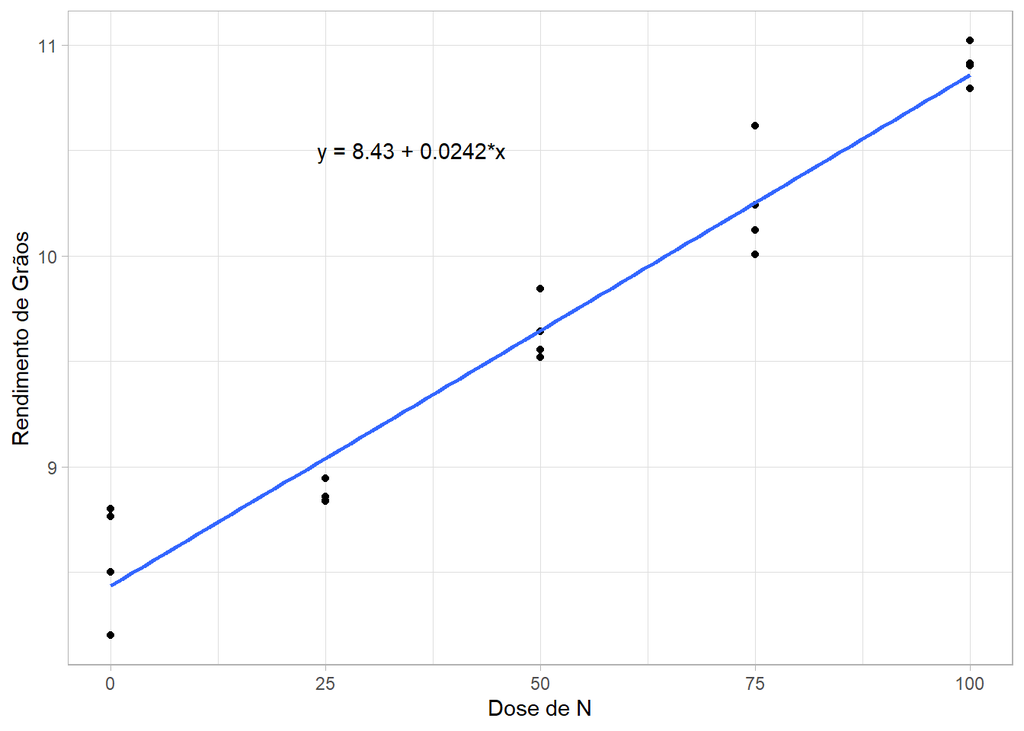

```r
# Visualização com a equação do modelo
df_reg |> ggplot(aes(DOSEN, RG)) +
  geom_point() +
  geom_smooth(se = FALSE, method = "lm") +
  annotate(geom = "text",
           x = 35,
           y = 10.5,
           label = "y = 8.43 + 0.0242*x") +
  labs(x = "Dose de N", y = "Rendimento de Grãos") +
  theme_light()
```

## 3. Regressão Polinomial e Otimização

Muitas vezes a resposta biológica não é linear, apresentando um ponto de saturação ou declínio. Nesses casos, usamos modelos de 2º grau (quadráticos).

```r
DOSEN <- c(0, 50, 100, 150, 200, 250)
RG    <- c(7.1, 7.3, 7.66, 7.71, 7.62, 7.6)
df2 <- data.frame(DOSEN = DOSEN, RG = RG)

# Comparação: Modelo Linear vs Polinomial
m_lin <- lm(RG ~ DOSEN, data = df2)
m_poly <- lm(RG ~ poly(DOSEN, 2, raw = TRUE), data = df2)

summary(m_lin)$r.squared
```

```
[1] 0.5984747
```

```r
summary(m_poly)$r.squared
```

```
[1] 0.9389192
```

**Interpretação Estatística:** O modelo linear explica apenas 59,8% da variação ($R^2 = 0.598$), enquanto o modelo polinomial explica 93,8% ($R^2 = 0.938$). Isso sugere que a relação é curvilínea.

### Cálculo da Dose de Máximo Rendimento

Para encontrar o ponto de máximo de uma parábola $y = ax^2 + bx + c$, calculamos $x = -b / 2a$.

```r
b <- coef(m_poly)[2] # Coeficiente linear
a <- coef(m_poly)[3] # Coeficiente quadrático

dose_max <- -b/(2*a)
dose_max
```

```
poly(DOSEN, 2, raw = TRUE)1
                   173.4138
```

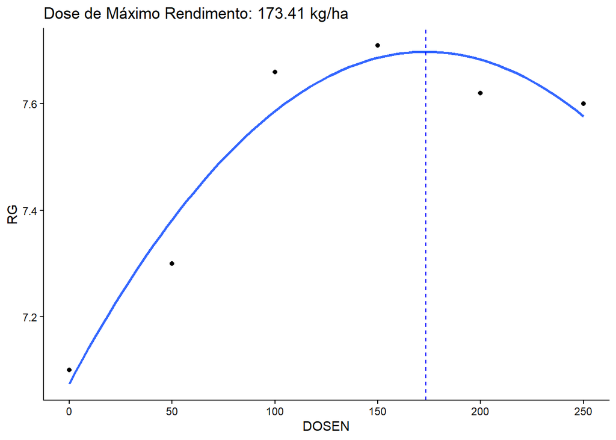

```r
# Visualização com a dose máxima destacada
df2 |> ggplot(aes(DOSEN, RG)) +
  geom_point() +
  geom_smooth(method = "lm", se = FALSE, formula = y ~ poly(x, 2)) +
  geom_vline(xintercept = dose_max, linetype = "dashed", color = "blue") +
  labs(title = paste("Dose de Máximo Rendimento:", round(dose_max, 2), "kg/ha")) +
  theme_classic()
```

## 4. Análise de Experimentos e Transformação de Dados

Ao analisar dados de contagem (como estande de plantas), os pressupostos de normalidade e homogeneidade de variância podem ser violados.

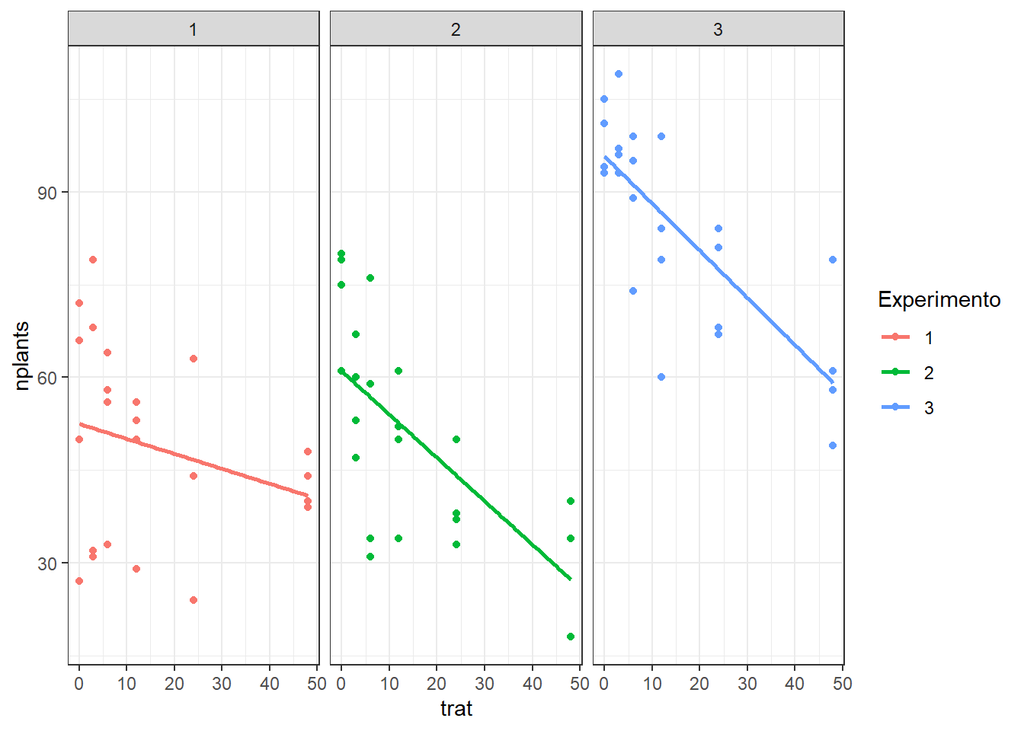

```r
estande <- gsheet2tbl("https://docs.google.com/spreadsheets/d/1bq2N19DcZdtax2fQW9OHSGMR0X2__Z9T/edit?gid=401662555#gid=401662555")

# Visualização por experimento
estande |> ggplot(aes(trat, nplants, color = factor(exp))) +
  geom_point() +
  geom_smooth(method = "lm", se = FALSE) +
  facet_wrap(~exp) +
  labs(color = "Experimento") +
  theme_bw()
```

### Transformação de Dados

A transformação para raiz quadrada ($\sqrt{Y}$) é comum para dados de contagem para estabilizar a variância.

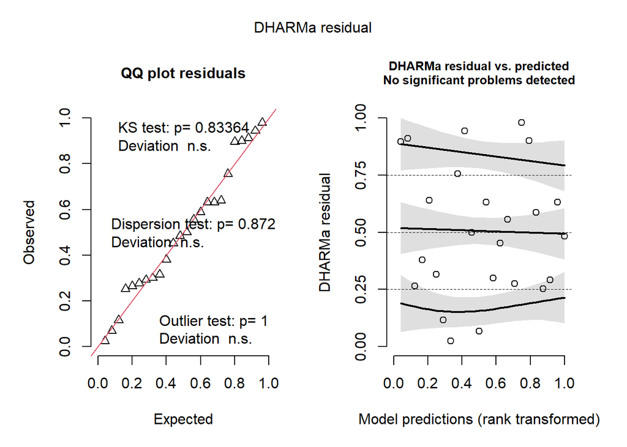

```r
exp1 <- estande |> filter(exp == 1)
m1_raw <- lm(nplants ~ trat + bloco, data = exp1)
m1_sqrt <- lm(sqrt(nplants) ~ trat + bloco, data = exp1)

# Verificação de resíduos com DHARMa
plot(simulateResiduals(m1_sqrt))
```

## 5. Modelos Mistos (Análise Conjunta)

Quando temos múltiplos experimentos, podemos usar modelos mistos onde o “Experimento” e o “Bloco” dentro do experimento são tratados como **efeitos aleatórios**, permitindo generalizar os resultados para além daqueles locais específicos.

```r
# Ajuste do modelo misto
# trat: efeito fixo
# (1|exp/bloco): efeito aleatório de bloco aninhado em experimento
m_mix <- lmer(nplants ~ trat + (1|exp/bloco), data = estande)

summary(m_mix)
```

```
Linear mixed model fit by REML ['lmerMod']
Formula: nplants ~ trat + (1 | exp/bloco)
   Data: estande

REML criterion at convergence: 575.8

Scaled residuals:
     Min       1Q   Median       3Q      Max
-2.21697 -0.63351  0.04292  0.67094  1.92907

Random effects:
 Groups    Name        Variance Std.Dev.
 bloco:exp (Intercept)  54.76    7.40
 exp       (Intercept) 377.43   19.43
 Residual              134.99   11.62
Number of obs: 72, groups:  bloco:exp, 12; exp, 3

Fixed effects:
            Estimate Std. Error t value
(Intercept) 69.74524   11.57191   6.027
trat        -0.56869    0.08314  -6.840

Correlation of Fixed Effects:
     (Intr)
trat -0.111
```

```r
Anova(m_mix) # Teste de Wald para o efeito fixo
```

|  | Chisq | Df | Pr(>Chisq) |
| --- | --- | --- | --- |
| trat | 46.78811 | 1 | 7.909164e-12 |

**Interpretação:** O efeito do tratamento (incidência de fungo) é altamente significativo. Para cada unidade de aumento na incidência, o estande de plantas diminui conforme o coeficiente estimado.

### Visualização Global do Modelo

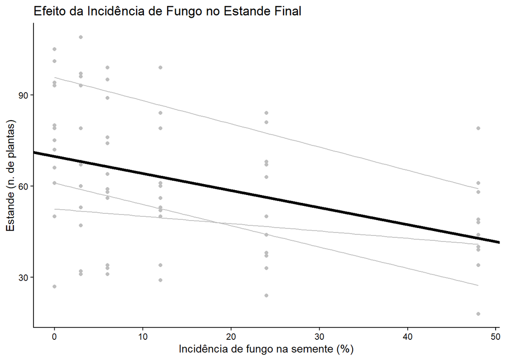

```r
# Gráfico com a tendência geral (linha preta) e dados individuais
estande |> ggplot(aes(trat, nplants, group = exp)) +
  geom_point(color = "gray") +
  geom_smooth(method = "lm", se = FALSE, color = "gray", size = 0.5) +
  geom_abline(intercept = 69.74, slope = -0.56, linewidth = 1.5, color = "black") +
  theme_classic() +
  labs(x = "Incidência de fungo na semente (%)",
       y = "Estande (n. de plantas)",
       title = "Efeito da Incidência de Fungo no Estande Final")
```